# Choi_j

Jane Choi

12/3/2019

### Pima Dataset:

```r
data  = read.csv('Pima.csv')
head(data)
```

```
##   pregnant glucose blood triceps insulin  bmi pedigree age test
## 1        0     100    70      26      50 30.8    0.597  21    0
## 2        0     100    88      60     110 46.8    0.962  31    0
## 3        0     101    62       0       0 21.9    0.336  25    0
## 4        0     101    64      17       0 21.0    0.252  21    0
## 5        0     101    65      28       0 24.6    0.237  22    0
## 6        0     101    76       0       0 35.7    0.198  26    0
```

-from a study conducted by the National Institute of Diabetes and Digestive and Kidney Disease on 768 adult female Pima Indians living near Phoenix.

### Research question and Hypothesis

“Relationship between average number of times pregnant and diabetes of Pima Indians”

–1 Is there evidence that Pima Indians having diabetes have a different average number of times pregnant than Pima Indians not having diabetes? (Independent samples t-test)

H0: There is no difference in average number of times pregnant between group with diabetes and group not having diabetes.

H1: There is difference in average number of times pregnant between group with and without diabetes.

–2 linear regression on having diabetes with pregnant number as the explanatory variable

### Data Analysis

#### Exploratory analysis :

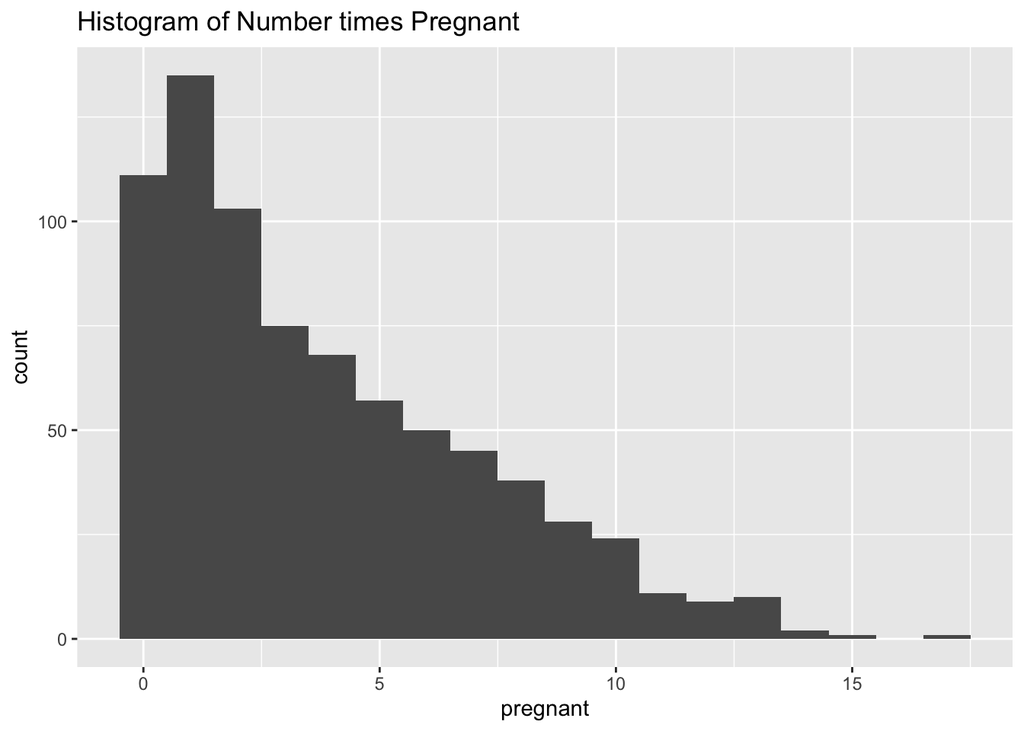

```r
#histogram = numerical data
ggplot(data , aes(pregnant)) +
  geom_histogram(binwidth = 1) +
  ggtitle('Histogram of Number times Pregnant')
```

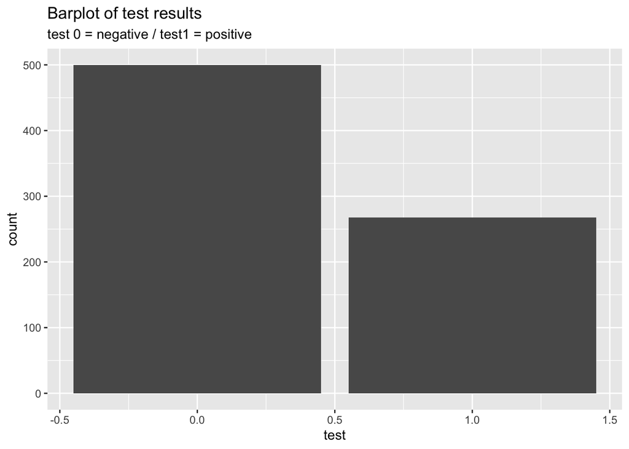

```r
#bar plot = categorical data
ggplot(data , aes(test)) +
  geom_bar()+
  ggtitle('Barplot of test results')+
  labs(subtitle = 'test 0 = negative / test1 = positive')
```

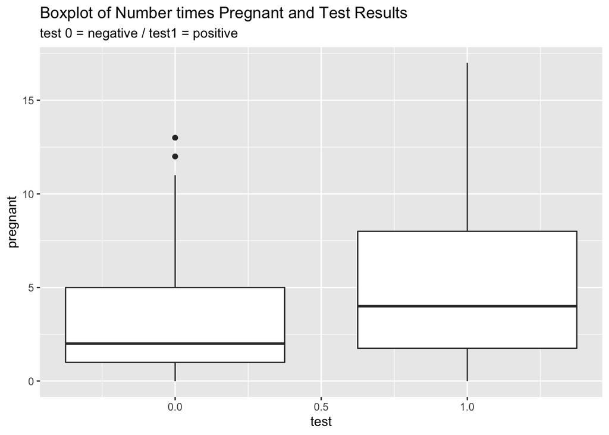

```r
ggplot(data=data, aes( x=test, y= pregnant, group =test ) )  + geom_boxplot() +
  ggtitle('Boxplot of Number times Pregnant and Test Results')+
  labs(subtitle = 'test 0 = negative / test1 = positive')
```

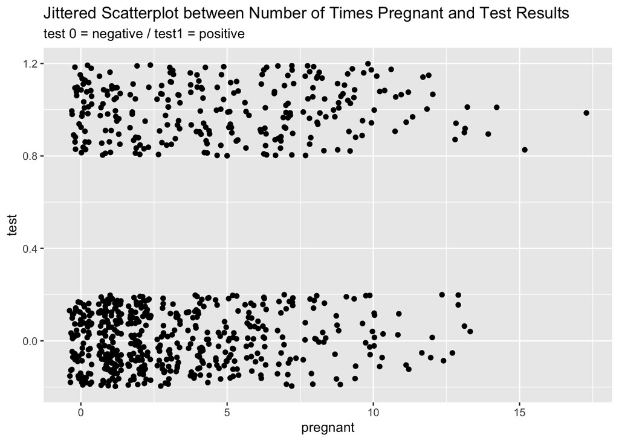

```r
ggplot(data ,aes(pregnant, test)) +
  geom_jitter(height = .2) +
  ggtitle('Jittered Scatterplot between Number of Times Pregnant and Test Results')+
  labs(subtitle = 'test 0 = negative / test1 = positive')
```

### Create a table with summary data.

Numerical value: sample size, mean (or median, if skewed) and standard deviation (or IQR, if skewed)

Divide the data into 2 groups:

GroupX: test result 0 (negative of diabetes) GroupY: test result 1 (positive of diabetes)

```r
X = data%>%
  filter(test == 0)

head(X)
```

```
##   pregnant glucose blood triceps insulin  bmi pedigree age test
## 1        0     100    70      26      50 30.8    0.597  21    0
## 2        0     100    88      60     110 46.8    0.962  31    0
## 3        0     101    62       0       0 21.9    0.336  25    0
## 4        0     101    64      17       0 21.0    0.252  21    0
## 5        0     101    65      28       0 24.6    0.237  22    0
## 6        0     101    76       0       0 35.7    0.198  26    0
```

```r
Y = data%>%
  filter(test == 1)

head(Y)
```

```
##   pregnant glucose blood triceps insulin  bmi pedigree age test
## 1        0     104    64      37      64 33.6    0.510  22    1
## 2        0     105    84       0       0 27.9    0.741  62    1
## 3        0     107    62      30      74 36.6    0.757  25    1
## 4        0     109    88      30       0 32.5    0.855  38    1
## 5        0     113    76       0       0 33.3    0.278  23    1
## 6        0     118    84      47     230 45.8    0.551  31    1
```

+new graph

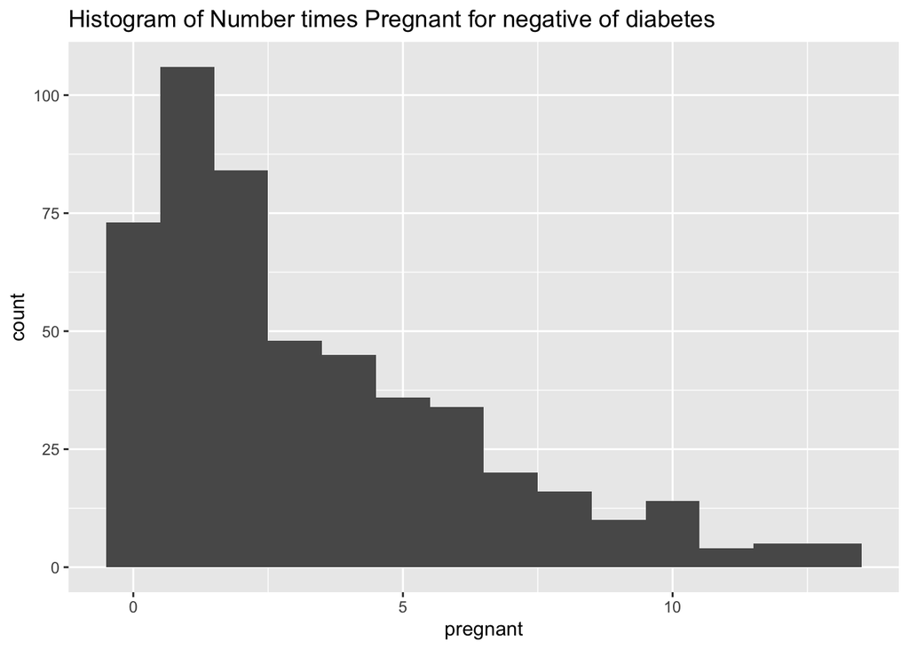

```r
ggplot(X , aes(pregnant)) +
  geom_histogram(binwidth = 1) +
  ggtitle('Histogram of Number times Pregnant for negative of diabetes')
```

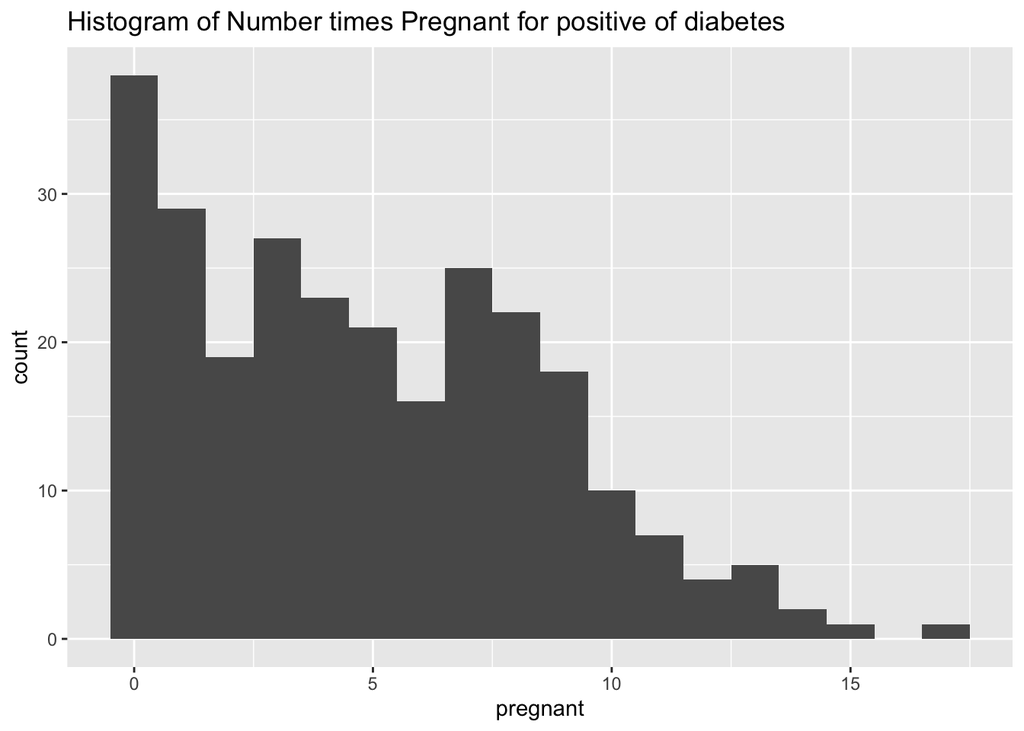

```r
ggplot(Y , aes(pregnant)) +
  geom_histogram(binwidth = 1) +
  ggtitle('Histogram of Number times Pregnant for positive of diabetes')
```

Group X: negative of diabetes

```r
nrow(X)
```

```
## [1] 500
```

```r
summary(X$pregnant)
```

```
##    Min. 1st Qu.  Median    Mean 3rd Qu.    Max.
##   0.000   1.000   2.000   3.298   5.000  13.000
```

```r
sd(X$pregnant)
```

```
## [1] 3.017185
```

```r
IQR(X$pregnant)
```

```
## [1] 4
```

Group Y: positive of diabetes

```r
nrow(Y)
```

```
## [1] 268
```

```r
summary(Y$pregnant)
```

```
##    Min. 1st Qu.  Median    Mean 3rd Qu.    Max.
##   0.000   1.750   4.000   4.866   8.000  17.000
```

```r
sd(Y$pregnant)
```

```
## [1] 3.741239
```

```r
IQR(Y$pregnant)
```

```
## [1] 6.25
```

Make a table for each value:

```r
summary.pregnant = as.data.frame(matrix(nrow= 3, ncol = 2))
colnames(summary.pregnant) = c('X', 'Y')
rownames(summary.pregnant) = c('mean', 'st.dev' , 'sample.size')
summary.pregnant[1,1] = mean(X$pregnant)
summary.pregnant[1,2] = mean(Y$pregnant)
summary.pregnant[2,1] = sd(X$pregnant)
summary.pregnant[2,2] = sd(Y$pregnant)
summary.pregnant[3,1] = nrow(X)
summary.pregnant[3,2] = nrow(Y)

summary.pregnant
```

```
##                      X          Y
## mean          3.298000   4.865672
## st.dev        3.017185   3.741239
## sample.size 500.000000 268.000000
```

Using the significance level of $\alpha = 0.05$

> 1. T-test for pregnant number

H0: There is no difference in average number of times pregnant between group with diabetes and group not having diabetes.

H1: There is difference in average number of times pregnant between group with and without diabetes.

```r
summary.pregnant
```

```
##                      X          Y
## mean          3.298000   4.865672
## st.dev        3.017185   3.741239
## sample.size 500.000000 268.000000
```

-Difference in sample means :

```r
d.s.m = summary.pregnant[1,2] - summary.pregnant[1,1]
d.s.m
```

```
## [1] 1.567672
```

-Standard error:

```r
se= sqrt((summary.pregnant[2,1])^2/summary.pregnant[3,1] + (summary.pregnant[2,2])^2/summary.pregnant[3,2])
se
```

```
## [1] 0.2653939
```

-Degrees of freedom:

```r
df= min(summary.pregnant[3,1]-1 , summary.pregnant[3,2] -1)
df
```

```
## [1] 267
```

-Test Statistic:

```r
t.s= d.s.m/se
t.s
```

```
## [1] 5.906961
```

-Critical value:

```r
t.c = qt(0.025, df, lower.tail = F)
t.c
```

```
## [1] 1.968889
```

P-value :

```r
2* pt(t.s, df, lower.tail = F)
```

```
## [1] 1.057504e-08
```

95% CI :

```r
d.s.m - t.c*se
```

```
## [1] 1.045141
```

```r
d.s.m + t.c*se
```

```
## [1] 2.090203
```

-Since the Test Statistic (5.9) is larger than the Critical value(1.96), the P-value is smaller than the significance level 0.05, and the 95% Confidence Interval doesn’t include the Null value(0) …

We reject the Null Hypothesis. There is sufficient evidence that there is difference in average number of times pregnant between group with and without diabetes.

> 2. linear regression for pregnant number

Make a new variable :

```r
#summary(data$pregnant)

data$pregnant.factor = NA

data[6 < data$pregnant , 'pregnant.factor']  <- mean(data[6 < data$pregnant,'pregnant' ] )


data[3<  data$pregnant & data$pregnant <=6, 'pregnant.factor']  <- mean(data[3<  data$pregnant & data$pregnant <=6,'pregnant' ] )

data[1 < data$pregnant & data$pregnant <=3, 'pregnant.factor']  <- mean(data[1 < data$pregnant & data$pregnant <=3, 'pregnant' ] )

data[data$pregnant <= 1, 'pregnant.factor'] <- mean(data[data$pregnant <= 1,'pregnant' ] )





table(data$pregnant.factor)
```

```
##
## 0.548780487804878  2.42134831460674  4.89714285714286  9.05325443786982
##               246               178               175               169
```

```r
pregnant.lm = lm(test~pregnant.factor, data = data)
summary(pregnant.lm)
```

```
##
## Call:
## lm(formula = test ~ pregnant.factor, data = data)
##
## Residuals:
##     Min      1Q  Median      3Q     Max
## -0.5300 -0.2995 -0.2344  0.4700  0.7656
##
## Coefficients:
##                 Estimate Std. Error t value Pr(>|t|)
## (Intercept)     0.215288   0.026236   8.206 9.66e-16 ***
## pregnant.factor 0.034764   0.005252   6.619 6.78e-11 ***
## ---
## Signif. codes:  0 '***' 0.001 '**' 0.01 '*' 0.05 '.' 0.1 ' ' 1
##
## Residual standard error: 0.4642 on 766 degrees of freedom
## Multiple R-squared:  0.05411,    Adjusted R-squared:  0.05287
## F-statistic: 43.82 on 1 and 766 DF,  p-value: 6.776e-11
```

## Results

Of the 768 women in the sample, 268 woman had the test results of positive of having diabetes.

Average number of pregnancy for women not having diabetes was 3.29 (SD = 3.0), while the average number of pregnancy for women having diabetes was 4.86 (SD = 3.7).

A linear regression model resulted in the following estimation equation:

## Conclusions

I found lower pregnancy numbers of women who are negative to the test(not having diabetes)

Other factors that might influence having diabetes are the glucose amount, bmi, insulin amount and other health related complications

Caution in pregnancy may have benefits for the Pima Indians not having diabetes.